# Categorizing Racial & Ethnic Identity in the US

SIPA U6614 | Instructor: Harold Stolper

# 1 Introduction: race, ethnicity, and “data for good”

Race and ethnicity are two aspects of personal identity that we’ll be using data to examine in different policy contexts. This document is a collection of observations based on short articles that can help us think about what to make of the data we encounter, what voices are represented/missing, and how to process data to better explore the connections between race, ethnicity and policy.

**What do we hope to achieve by analyzing data on different aspects of personal identity? What should we avoid doing?** Data can help improve transparency from our institutions and [disrupt algorithmic bias](https://www.jstor.org/stable/10.5325/jinfopoli.8.2018.0078#metadata_info_tab_contents). Data can amplify personal stories and lived experience. But it can also be [reductive](https://twitter.com/BlackDisability/status/1297996682232246274).

**What would “better” data look like, and what could we do with it?** Richer and more nuanced data on personal identity can help us better understand the ways that systems of oppression interact with different aspects of identity to limit opportunity. And inform more equitable policies and notions of distributive/restorative justice.

**How do we get the most of the limited data we have access to now? How do we use the data at hand for “good”? What information are we missing and what are the implications?** These are questions that we will come back to throughout the semester, as we learn from each other about what data we’d like to see exist in the future and what “data for good” should look and feel like.

# 2 US Census categories: the limits of taking identity data at face value

Every 10 years the US conducts a Census to take stock of who lives in the country. This data is used to inform funding levels for federal programs and civil rights policies.

The evolution of race and ethnicity categories recognized in the US Census demonstrates how race is a plainly social construct. Consider the history of racial categories in the Census for Asians, as summarized by the [Pew Research Center](https://www.pewresearch.org/fact-tank/2020/02/25/the-changing-categories-the-u-s-has-used-to-measure-race/):

> The first racial category for Asians was introduced nationwide in 1870 with “Chinese, reflecting increased concern over immigration as many people came from China to work on the Central Pacific Railroad. In 1910, “Other” was offered as a race category for the first time, but the vast majority of those who selected it were Korean, Filipino and Asian Indian. “Other” or “Some other race” was included on most subsequent questionnaires, encompassing a broader range of races, and the Asian racial categories were later expanded. Asian Indians were called “Hindus” on the census form from 1920 to 1940, regardless of religion. Beginning in 2000, people could select from among six different Asian groups in addition to “Other Asian,” with the option to write in a specific group."

[Vox](https://www.vox.com/2016/8/18/12404688/census-race-history-intersectionality) explains how somebody who identified as Hispanic or Latino has been counted by the decennial US Census over time:

- *In 1930, someone who identified as Hispanic or Latino was counted by the census as **MEXICAN**.*
- *In 1960, someone who identified as Hispanic or Latino **WAS NOT COUNTED BY THE CENSUS**.*
- *In 2000, someone who identified as Hispanic or Latino was counted by the census as **MEXICAN, MEXICAN AMERICAN, CHICANO, PUERTO RICAN, CUBAN, OR OTHER SPANISH/HISPANIC/LATINO**.*

Federally recognized categories evolved along with social context about what it means to be Hispanic or Asian in the US, for example… but not according to any clear and consistent logic. Race and ethnicity data is thus limited by institutional definitions of race and ethnicity identity.

One takeaway for policy analysis is not to take the pre-defined categories at face value, but to think about recoding race and ethnicity data into identity categories that are most meaningful given the policy context under study.

#### 2020 Census questions on race:

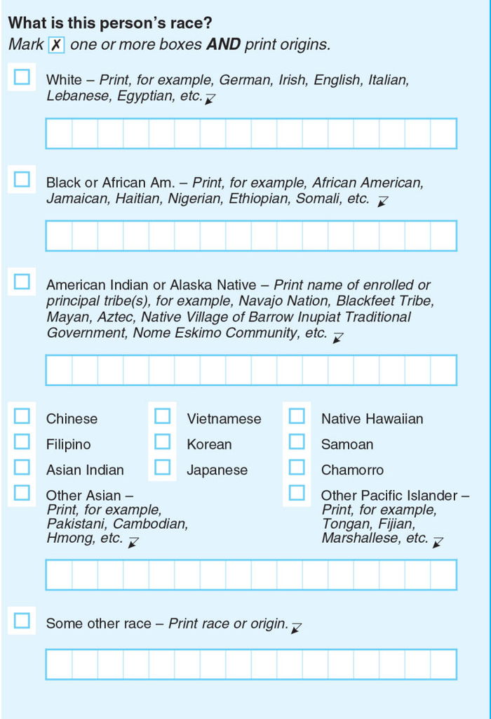

# 3 Multi-dimensional identity and intersectionality

Simplicity is often a good thing that can make information more accessible, but reducing people to a single dimension of identity is obviously limiting in many ways. Modeling how intersectional identity relates to outcomes should allow for [multiplicative interactions](https://weallcount.com/2019/06/21/intersectionality-data-2/) between dimensions of identity rather than additively separable components of identity.

But what if the data and surrounding discourse focus on measures that reduce multiracial/ethnic identity to a single dimension? Is a desire to simplify (and sample size limitations) a valid reason to assign individuals to one of several mutually exclusive identity categories. Which identity category should an individual who identifies as both Black and Latinx individuals be assigned to? Would assigning them to a separate multiracial category add valuable context, or would it muddle our understanding of what it means to be Black and Latinx, respectively, by assigning them to a third category? Is this sort of simplification just too reductive?

How much should the context impact the specific approach to coding identity? For example, should Hispanic identity be more salient in an analysis examining the role of native English fluency? If the focus is on policing and colourism, should Black racial identity be centered in the analysis?

Or even better, maybe we can restructure the data to measure the prevalence of a certain dimension of identity within broader groups (e.g. neighborhoods or cohorts) rather than prescribing limited measures of identity to individuals. This sort of aggregation is something we’ll come back to when we study NYPD enforcement in the coming weeks.

# 4 Should we use more “progressive” identity labels?

Identity is deeply personal, and so are the labels people use. The Census asks people if they identify as “Hispanic, Latino, or Spanish origin.” Some unknown share of younger, progressive Americans who would say they identify as Hispanic might prefer to identify as Latinx, for example. When presenting your own analysis of raw data that uses gendered race and ethnicity labels with colonial roots, should you replace them with more progressive, gender-neutral labels?

My own opinion is an unsatisfying… maybe. Would your decision to relabel Hispanic identity as Latinx substantially misrepresent the underlying data, or enrich the meaning of identity on balance? How will the identity labels affect how different audiences engage with your analysis?

[video not shown]

This [Vice News](https://www.youtube.com/watch?v=0Zx4m2ok6D0) video is a good reminder that racial identity labels are necessarily limiting and our own notions of identity justice may not align with how other people identify. This [Fox News](https://www.foxnews.com/world/how-do-latinos-prefer-to-be-identified-hint-not-as-latinos-asks-study) piece take a very different tone on how “Latinos prefer to be identified.”

The New York Times didn’t start [capitalizing Black](https://www.nytimes.com/2020/07/05/insider/capitalized-black.html) until July 5, 2020. stating “we believe this style best conveys elements of shared history and identity, and reflects our goal to be respectful of all the people and communities we cover.” The Times National editor explained that “there was a growing agreement in the country to capitalize and that The Times should not be a holdout” (sidebar: how “liberal” of the Times).

# 5 The missing MENA category

Lam Thuy Vo explains in her article for [Vox](https://www.vox.com/2016/8/18/12404688/census-race-history-intersectionality) that, according to the US Office of Management and Budget, “someone classified as White is someone who has origins in any of the original peoples of Europe, the Middle East, or North Africa”. In other words, as far as the federal government is concerned, Arabs, Iranians and others of the Middle East and North Africa (MENA) descent are considered white. [Al Jazeera](https://www.aljazeera.com/news/2020/04/mena-category-2020-census-200401114334500.html) summarizes recent (failed) attempts at adding the MENA category to the Census:

> A MENA category would represent a diverse set of dismissed identities with specific needs … Getting census data would be a good start to meet those needs.

Samer Khalaf, the national president of American-Arab Anti-Discrimination Committee (ADC), explains that the exclusion of the MENA category was a politicized act: “Why? If you take Arabs out of the white category, it’s going to drop.”

# 6 Disaggregating data for Asian sub-groups in NY

Late last year, the governor of New York vetoed State Assembly Bill 677 that would have required state agencies to collect data disaggregated by specific Asian, Pacific Islander and Native Hawaiian ethnicities, such as Vietnamese, Hmong and Bangladeshi. The following borrows heavily from Navjot’s Kaur’s article for [Medium](https://medium.com/@KaurRepublic/the-veto-of-asian-american-and-pacific-islanders-in-new-york-state-d2655cefd06a) and Kimmy Yang’s article for [NBC News](https://www.nbcnews.com/news/asian-america/gov-cuomo-vetoes-bill-would-have-helped-underserved-asian-americans-n1101681).

Why the need for disaggregated data on Asian ethnicity? Kimmy Yang explains:

> While the “model minority myth” suggests that the community is financially well off, research shows that those from the Cambodian and Laotian communities, among others, are more economically vulnerable compared to those from the Chinese or Indian communities, a 2018 report on Asian American wealth disparity points out. Disaggregated data on Asian American and Pacific Islander median household income shows while Bangladeshi Americans make a median of $46,950, Indian Americans make $95,000.

Yang goes on to note how the bill could have resulted in better policy:

> The bill would have not only prevented exclusion, but more precise data would also uncover hidden challenges the AAPI communities face and aid legislators in figuring out how and where to allocate resources, [Assemblywoman] Niou said. Existing services including poverty relief, health outcome improvement programs, and language access within the programs could be made more effective.

In addition to budgetary concerns, Governor Cuomo cited privacy concerns as another reason for his veto:

> Cuomo also wrote that he was concerned the bill’s requirement to collect data on “an individual’s place of birth and national origin will have unintended consequences” given the “overly aggressive” approach the Trump administration has taken to immigration enforcement.

Advocated countered that existing data gaps pose a bigger threat:

> But the unintended consequences of inaccurate data to meet the needs of AAPI and immigrant communities pose a greater threat, Carlyn Cowen, CPC’s chief policy and public affairs officer said.

# 7 Discussion questions for next class

- Do you support passing a law such as Assembly Bill 677 to required state agencies to disaggregate data and collect information on specific Asian, Pacific Islander and Native Hawaiian ethnicities, such as Vietnamese and Nepalese? What are the downsides? Are there better ways to target public resources to helping relatively more marginalized Asian sub-groups?
- Where do you think Black Hispanic women do/should fit into the below graphic? Why do you think it does/doesn’t matter?

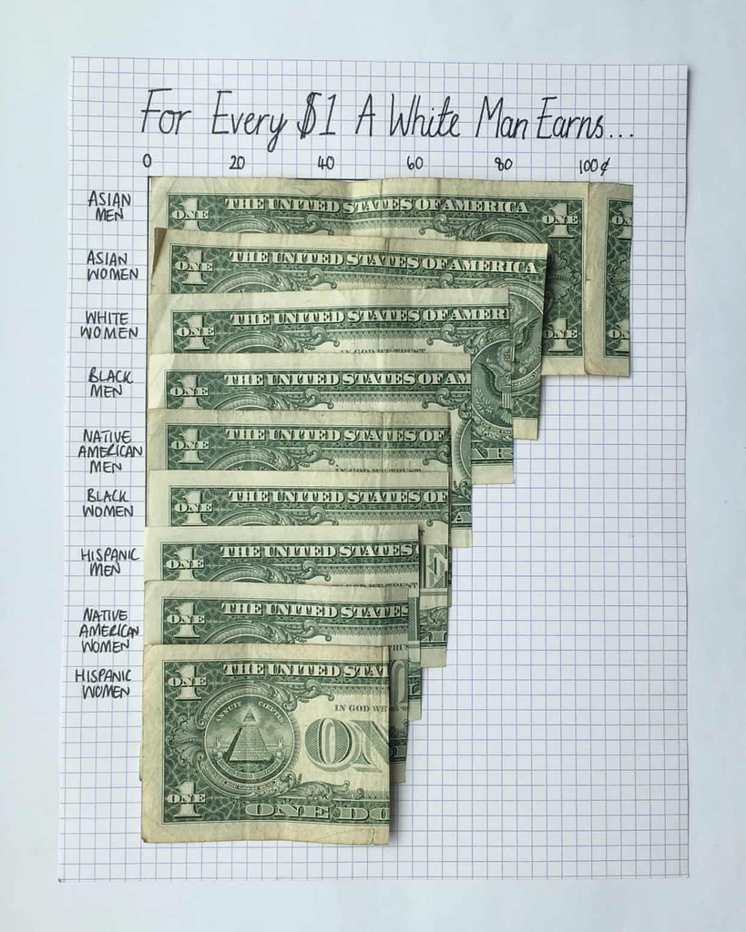

Source: [The Guardian](https://www.theguardian.com/us-news/datablog/2017/apr/04/equal-pay-day-us-wage-gap-gender-race-ethnicity) and @monachalabi on Instagram